# Problem Set 6: Regression Discontinuity

Claire Duquennois

*Name:* Kiersten Kochanowski

Instructions:

- This assignment is an individual assignment. You may discuss your responses in small groups or reach out to a classmate if you are having difficulties with coding but your code and answers must reflect your individual efforts and be written using your own words. Identical assignments will be given a zero grade.
- You must post your code in a private repo on GitHub and invite Neil and I as collaborators.
- You must update your work on GitHub frequently through commits where we can observe which lines you most recently worked on when we click on the repo history. This is done very easily if you are using Git correctly which is part of what we are assessing with this assignment. Make sure you make at least five commits that highlight your most recent changes.

# 1 Empirical Analysis using Data from Manacorda, Miguel, & Vigorito (2011, American Economic Journal: Applied Economics)

This exercise uses data from Manacorda, Miguel, & Vigorito’s paper, “Government Transfers and Political Support,” published in the *American Economic Journal: Applied Economics* in 2011. This paper studies how receipt of a government anti-poverty cash transfer changes how beneficiary households support and view the government.

# 2 Finding the data

The data can be found on Edward Miguel’s faculty website. Download and extract the contents from the `Government_Transfers_replication.zip` file.

# 3 Set up and constructing the data

The original data used in the paper is confidential. The authors instead provide the `reg_panes.dta` data file which is anonymized and created from the original data.

## 3.1 Question 1: Loading the Packages

Load any R packages you will be using: **Code:**

```r
library(haven)
library(dplyr)
library(stargazer)
library(lfe)
library(tidyverse)
#install.packages("statar")
library(statar)
```

```r
library(ggplot2)
```

## 3.2 Question 2: Open the `reg_panes.dta` file. To complete this problem set you will need the following variables from this data file:

| Name | Description |
| --- | --- |
| aprobado | Ever received PANES 2005-2007 |
| untracked07 | Untracked in 2007 |
| h_89 | Supports current government 2007 [1 to 3] |
| hv34 | Supports current government 2008 [1 to 3] |
| ind_reest | Predicted Income |
| newtreat | PANES eligibility |
| geo | Geographic locality |
| bl_medad | Mean age |
| lnbl_ytoth_pc | Log per capita income |
| bl_hhsize | Mean household size |
| bl_meduc | Mean education |
| missbl_medad | Missing mean age |
| misslnbl_ytoth_pc | Missing log per capita income |
| missbl_hhsize | Missing mean household size |
| missbl_meduc | Missing mean education |
| sexo | Respondent is female |
| edad | Respondent age |
| aniosed07 | Education in 2007 |
| misssexo | Missing gender |
| missedad | Missing age |
| missaniosed | Missing education |

Drop all other variables. If needed, give the variables you are keeping more intuitive names.

**Code:**

```r
reg_panes_orig <- read_dta("/Users/Kiersten/Documents/School/S2_Causal_Inf/PS6_Kochanowski/Data/reg_panes.dta")
View(reg_panes_orig)
reg_panes <- select(reg_panes_orig, aprobado, untracked07, h_89, hv34, ind_reest, newtreat, geo, bl_medad, lnbl_ytoth_pc, bl_hhsize, bl_meduc, missbl_medad, misslnbl_ytoth_pc,missbl_hhsize, missbl_meduc, sexo, edad, aniosed07, misssexo, missedad, missaniosed)
#View(reg_panes)
```

## 3.3 **Question 3: The data as downloaded will require that you clean the variables of interest and construct a new dataset to generate the graphs. Start by generating the following cleaned variable:**

-An indicator for receiving PANES that is NA if a respondent is untracked in 2007

**Code:**

```r
reg_panes$treat<-reg_panes$aprobado
reg_panes$treat[reg_panes$untracked07==1]<-NA

#Variable for PANES eligibility
reg_panes$eligible<-0
reg_panes$eligible[reg_panes$ind_reest>=0]<- 0
reg_panes$eligible[reg_panes$ind_reest<0]<- 1
reg_panes$eligible[reg_panes$untracked07==1]<-NA
```

## 3.4 **Question 4: We are going to re-scale the variables that indicate support for the current government so that responses range from 0 to 1. To do this, tabulate the current variable to see how it is distributed and then generate a variable that will be NA if it is currently coded as 9, 0 if currently 2, 0.5 if currently 1 and 1 if currently 3. Do this for both the 2007 and 2008 variable.**

Note: This is how the authors modify this variable in their code. It seems counter intuitive and does not correspond to the description of how this variable is coded in the survey questionnaire as reported in their appendix though it does correspond to their discussion in footnote 12. My guess is the transcription/translation of the survey question is incorrect.

**Code:**

```r
#2007
reg_panes$sup07<-NA
reg_panes$sup07[reg_panes$h_89==1]<-0.5
reg_panes$sup07[reg_panes$h_89==2]<-0
reg_panes$sup07[reg_panes$h_89==3]<-1
reg_panes$sup07[reg_panes$h_89==9]<-NA
table(reg_panes$h_89)
```

```
##
##    1    2    3    9
##  397  122 1570  130
```

```r
table(reg_panes$sup07)
```

```
##
##    0  0.5    1
##  122  397 1570
```

```r
reg_panes$sup07 <- as.numeric(reg_panes$sup07)

#2008
reg_panes$sup08<-NA
reg_panes$sup08[reg_panes$hv34==1]<-0.5
reg_panes$sup08[reg_panes$hv34==2]<-0
reg_panes$sup08[reg_panes$hv34==3]<-1
reg_panes$sup08[reg_panes$hv34==9]<-NA
table(reg_panes$hv34)
```

```
##
##    1    2    3    9
##  476  159 1313  103
```

```r
table(reg_panes$sup08)
```

```
##
##    0  0.5    1
##  159  476 1313
```

```r
reg_panes$sup08 <- as.numeric(reg_panes$sup08)
```

## 3.5 **Question 5: Generate a variable that is the square of predicted income.**

**Code:**

```r
reg_panes$ind_reest_sqd <- reg_panes$ind_reest^2
```

# 4 We start by reproducing the main figures (2,3,and 4) of the paper as good figures are key to any regression discontinuity paper.

## 4.2 **Question 7: Why is the number of points above the threshold different from the number below?**

**Answer:** The study wanted to gather more information on treatment recipient households so they split the sample between eligible and ineligible 2:1. This was likely for budget concern reasons - wanting to spend more resources on insight from the treatment group than collecting information from more households in the ineligible group.

## 4.3 **Question 8: Replicating these figures will require restructuring our data and calculating the values that are plotted. Generate a variable that will indicate the percentile group the observation is in. Note the difference in the number of percentile groups above and below the threshold.**

Note: you may find the `xtile` function in R useful.

**Code:**

```r
#Disqualifying households with invalid responses to government support question
nrow(reg_panes)
```

```
## [1] 3098
```

```r
reg_panes$incscore <- reg_panes$ind_reest
reg_panes$incscore[is.na(reg_panes$sup07)]<-NA
reg_panes$incscore[is.na(reg_panes$sup08)]<-NA
reg_panes$incscore[is.na(reg_panes$treat)]<-NA
#View(reg_panes)

#Incscore already standardized around 0 (first negative score is below threshold (i.e. treated))
```

```r
# Run for loop to make cuts below threshold
y <- -0.01999099

sample_below <- c()

for(i in 1:30) {
  y <- sum(y+0.00064307)
  sample_below <- c(sample_below, y)
}

# Run for loop to make cuts above threshold
x <- 0.01989200

sample_above <- c()

for(i in 1:15) {
  x <- sum(x-0.0012368)
  sample_above <- c(sample_above, x)
}
print(sample_below)
```

```
##  [1] -0.01934792 -0.01870485 -0.01806178 -0.01741871 -0.01677564 -0.01613257
##  [7] -0.01548950 -0.01484643 -0.01420336 -0.01356029 -0.01291722 -0.01227415
## [13] -0.01163108 -0.01098801 -0.01034494 -0.00970187 -0.00905880 -0.00841573
## [19] -0.00777266 -0.00712959 -0.00648652 -0.00584345 -0.00520038 -0.00455731
## [25] -0.00391424 -0.00327117 -0.00262810 -0.00198503 -0.00134196 -0.00069889
```

```r
#Create cuts vector
cuts <- c(sample_below, sample_above)
print(cuts)
```

```
##  [1] -0.01934792 -0.01870485 -0.01806178 -0.01741871 -0.01677564 -0.01613257
##  [7] -0.01548950 -0.01484643 -0.01420336 -0.01356029 -0.01291722 -0.01227415
## [13] -0.01163108 -0.01098801 -0.01034494 -0.00970187 -0.00905880 -0.00841573
## [19] -0.00777266 -0.00712959 -0.00648652 -0.00584345 -0.00520038 -0.00455731
## [25] -0.00391424 -0.00327117 -0.00262810 -0.00198503 -0.00134196 -0.00069889
## [31]  0.01865520  0.01741840  0.01618160  0.01494480  0.01370800  0.01247120
## [37]  0.01123440  0.00999760  0.00876080  0.00752400  0.00628720  0.00505040
## [43]  0.00381360  0.00257680  0.00134000
```

```r
midpoints_below <- cuts[2:30]-0.00032154
midpoints_above <- cuts[31:45]-0.0006184
midpoints <- c(midpoints_below, midpoints_above)


#Create bins
reg_panes$percentiles <- cut(reg_panes$incscore, breaks=cuts, include.lowest = TRUE, right=FALSE, labels=midpoints)
View(reg_panes)
```

## 4.4 **Question 9: For each of the percentile groups, calculate the mean of each of the variables we will use for plotting: predicted income, receipt of PANES, support for the government in 2007, and support for the government in 2008.**

**Code:**

```r
#Calculating means
reg_panes_sharp <- reg_panes %>%
  group_by(percentiles) %>%
  summarize(scoremean = mean(ind_reest, na.rm=TRUE), treatmean = mean(aprobado, na.rm=TRUE), sup07mean = mean(sup07, na.rm=TRUE), sup08mean = mean(sup08, na.rm=TRUE), numb=n())
#View(reg_panes_sharp)
```

## 4.5 **Question 10: Replicate figure 2. Make the figure as clear and informative as possible. You may want to create an indicator variable for percentiles above and below the threshold.**

**Code:**

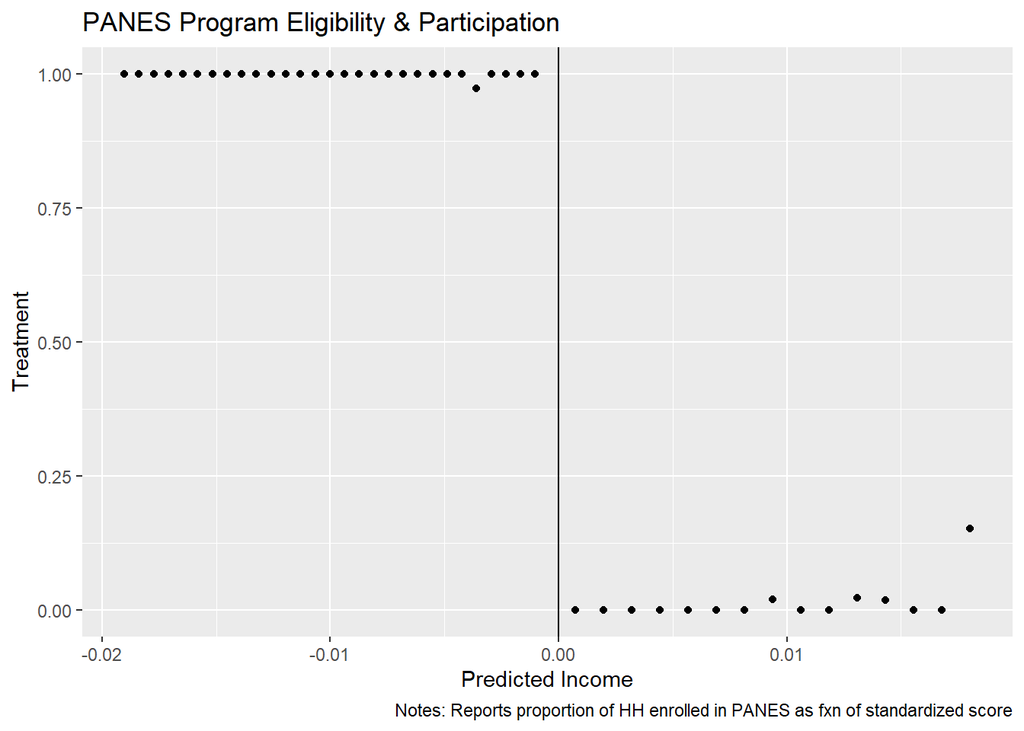

```r
reg_panes_sharp$percentiles <- as.numeric(as.character(reg_panes_sharp$percentiles))

plot1 <- ggplot(reg_panes_sharp, aes(x=percentiles, y=treatmean)) +               geom_point() +
        geom_vline(aes(xintercept = 0)) + labs(x = "Predicted Income", y = "Treatment",
 title ="PANES Program Eligibility & Participation",
 caption = "Notes: Reports proportion of HH enrolled in PANES as fxn of standardized score")

plot1
```

## 4.6 **Question 11: What is the purpose of this figure and what should we take away from it?**

**Answer:** Overall the figure shows that the implementation of treatment was honest and sharp, where virtually all households that qualified for treatment received treatment (given the percentile averages are consistently 1) and the households that did not qualify (above the threshold) did not receive treatment (given the percentile averages are consistently around 0)

## 4.7 **Question 12: Replicate figures 3 and 4. Make these figures as clear and informative as possible.**

**Code:**

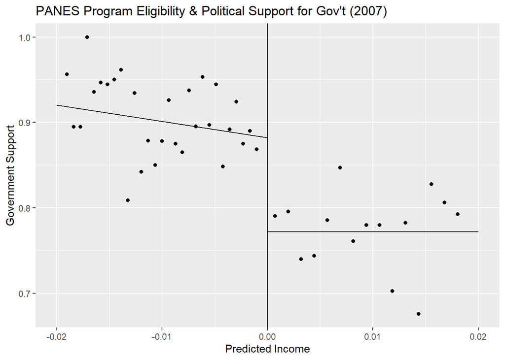

```r
#Line of best fit
sharpestim <- felm(data=reg_panes, sup07 ~ eligible + ind_reest + eligible*ind_reest|0|0|ind_reest)

#Plot
plot2 <- ggplot(reg_panes_sharp, aes(x=percentiles, y=sup07mean)) +
        geom_point() +
        geom_vline(aes(xintercept = 0)) +
        geom_segment(aes(x=0, xend=0.02, y=sharpestim$coefficients[1], yend=sharpestim$coefficients[1] +0.02*sharpestim$coefficients[3])) +
        geom_segment(aes(x=-0.02, xend=0, y=sharpestim$coefficients[1] + sharpestim$coefficients[2] +(-0.02*(sharpestim$coefficients[3]+sharpestim$coefficients[4])), yend = sharpestim$coefficients[1]+sharpestim$coefficients[2]))+
        labs(x = "Predicted Income", y = "Government Support",
        title ="PANES Program Eligibility & Political Support for Gov't (2007)")

plot2
```

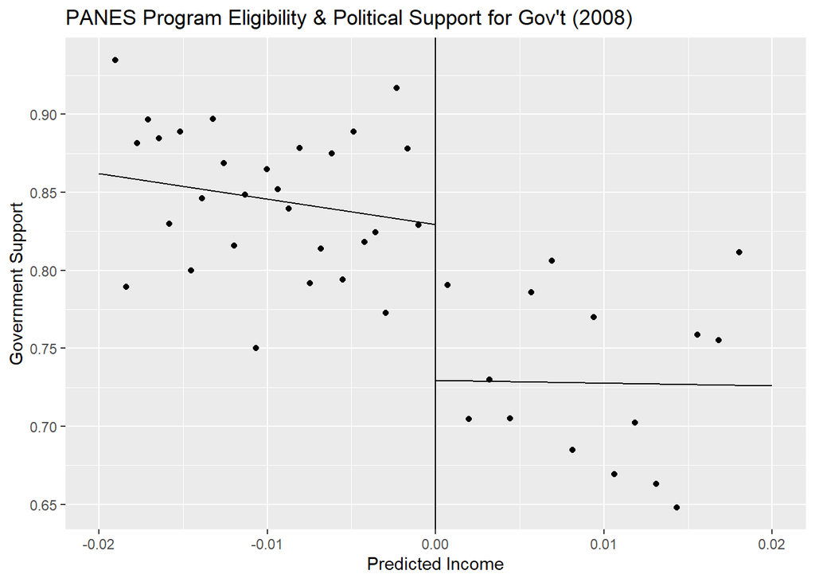

```r
#Line of best fit
sharpestim2 <- felm(data=reg_panes, sup08 ~ eligible + ind_reest + eligible*ind_reest|0|0|ind_reest)

plot3 <- ggplot(reg_panes_sharp, aes(x=percentiles, y=sup08mean)) +
        geom_point() +
        geom_vline(xintercept = 0) +
        geom_segment(aes(x=0, xend=0.02, y=sharpestim2$coefficients[1], yend=sharpestim2$coefficients[1] +0.02*sharpestim2$coefficients[3])) +
        geom_segment(aes(x=-0.02, xend=0, y=sharpestim2$coefficients[1] + sharpestim2$coefficients[2] +(-0.02*(sharpestim2$coefficients[3]+sharpestim2$coefficients[4])), yend = sharpestim2$coefficients[1]+sharpestim2$coefficients[2]))+
        labs(x = "Predicted Income", y = "Government Support",
        title ="PANES Program Eligibility & Political Support for Gov't (2008)")

plot3
```

## 4.8 **Question 13: Interpret these figures. What should we take away from them?**

**Answer:** We can see a significant discontinuity in government support between households that received PANES and those that didn’t. We can take away that the difference (gap) along the threshold (0) represents the existence of a treatment effect (although we can’t quantify it using these graphs). In both 2007 (during the administration), households that received PANES were significantly more supportive of the current government than households just above the threshold (with normalized income score <= 0.02). The same relationship held after the PANES program ended in 2008 (second figure).

## 4.9 **Question 14: Replicate the results of the three regressions estimated in the first column of table 1. Present your results in a table. Interpret the coefficients.**

**Code:**

```r
#reg_panes2 <- as.data.frame(reg_panes2)
#reg_panes2$incscore_sqrd <- reg_panes2$incscore^2
reg_panes <- as.data.frame(reg_panes)
reg_panes$ind_reest_sqd <- (reg_panes$ind_reest)^2
#View(reg_panes)

#Row 1 (Ever received PANES)
r1 <- felm(data=reg_panes, aprobado ~ eligible|0|0|ind_reest)
#Create clustered se for stargazer
cluster_se1 <- as.vector(summary(r1,cluster = c("ind_reest"))$coefficients[,"Cluster s.e."])

#Row 2 (government support '07)
r2 <- felm(data=reg_panes, sup07 ~ eligible |0|0|ind_reest)
#Create clustered se for stargazer
cluster_se2 <- as.vector(summary(r2,cluster = c("ind_reest"))$coefficients[,"Cluster s.e."])

#Row 3 (government support '07)
r3 <- felm(data=reg_panes, sup08 ~ eligible|0|0|ind_reest)
#Create clustered se for stargazer
cluster_se3 <- as.vector(summary(r3,cluster = c("ind_reest"))$coefficients[,"Cluster s.e."])


stargazer(r1, r2, r3, type="html", header=FALSE, title="PANES Eligibility, Participation & Political Support for Government",
                     style="qje",
                     se = list(r1$cluster_se1, r2$cluster_se2, r3$cluster_se3),
                     covariate.labels = c("Eligible"),
                     dep.var.labels.include = TRUE,
                     omit = c("Constant"),
                     add.lines = list(c("Score controls", "None", "None", "None")))
```

**PANES Eligibility, Participation & Political Support for Government**

|  | aprobado | sup07 | sup08 |
| --- | --- | --- | --- |
|  | (1) | (2) | (3) |
| Eligible | 0.993*** | 0.129*** | 0.118*** |
|  | (0.002) | (0.013) | (0.015) |
| Score controls | None | None | None |
| *N* | 2,232 | 2,089 | 1,948 |
| R<sup>2</sup> | 0.987 | 0.050 | 0.034 |
| Adjusted R<sup>2</sup> | 0.987 | 0.049 | 0.033 |
| Residual Std. Error | 0.056 (df = 2230) | 0.280 (df = 2087) | 0.313 (df = 1946) |
| *Notes:* | ***Significant at the 1 percent level. |  |  |
|  | **Significant at the 5 percent level. |  |  |
|  | *Significant at the 10 percent level. |  |  |

**Answer:** R1: aprobado ~ eligible: estimates the effect of PANES eligibility on program receipt. This means 99.3% of households eligible for PANES received the support (relatively sharp RD) R2: sup07 ~ eligible: estimates the effect of PANES eligibility on government support in 2007. At the margin, households that are eligible for PANES result in ~13% increase in support for the FA administration R3: sup08 ~ eligible: estimates the effect of PANES eligibility on government support in 2008. At the margin, households that are eligible for PANES result in ~12% increase in support for the FA administration

## 4.10 **Question 15: Write down the specifications used in row 2 of columns 1,2 and 3 of table 1.**

$$

$$\begin{aligned}
GovSupp07_i&=\beta_0+\beta_1Eligible_i+\epsilon_i\\
GovSupp07_i&=\beta_0+\beta_1Eligible_i+\beta_2(Score-Threshold)+\beta_3(Score-Threshold)*Eligible+\epsilon_i\\
GovSupp07_i&=\beta_0+\beta_1Eligible_i+\beta_2(Score-Threshold)+\beta_3(Score-Threshold)^2+\beta_4(Score-Threshold)*Eligible+\beta_5(Score-Threshold)^2*Eligible+\epsilon_i\\
\end{aligned}$$

$$

The dependent variable is political support for the government in the first follow-up survey in 2007. These regressions only use observations with valid responses from the 2007 survey. Similar to the first row, these regressions use the explanatory variable (eligible), the standardized score (ind_reest) and the interaction term of these two variables (representing the treatment effect). Each regression employs different parameterizations of the standardize running variable (ind_reest): no polynomial, first order polynomial (linear), and quadratic polynomial.

## 4.11 **Question 16: Replicate all of the results reported in row 2 of Table 1. Explain the difference between these specifications and interpret their coefficients.**

Hint: the variables listed in the table above after newtreat are the controls you will want to include.

**Code:**

```r
#Changing class when necessary
class(reg_panes$geo)
reg_panes$geo <- as.character(reg_panes$geo)

class(reg_panes$lnbl_ytoth_pc)
class(reg_panes$bl_meduc)
class(reg_panes$bl_medad)
class(reg_panes$bl_hhsize)

class(reg_panes$sexo)
reg_panes$sexo <- as.character(reg_panes$sexo)
class(reg_panes$sexo)

class(reg_panes$edad)
class(reg_panes$aniosed07)
class(reg_panes$misslnbl_ytoth_pc)
class(reg_panes$missbl_meduc)
class(reg_panes$missbl_medad)
class(reg_panes$missbl_hhsize)
class(reg_panes$missedad)
class(reg_panes$misssexo)

class(reg_panes$missaniosed)
reg_panes$missaniosed <- as.character(reg_panes$missaniosed)
class(reg_panes$missaniosed)

class(reg_panes$geo)
```

```r
#View(reg_panes2)

#No polynomial
r4 <- felm(data=reg_panes, sup07 ~ eligible|0|0|ind_reest)
#Create clustered se for stargazer
cluster_se4 <- as.vector(summary(r4,cluster = c("ind_reest"))$coefficients[,"Cluster s.e."])

#First order polynomial
r5 <- felm(data=reg_panes, sup07 ~ eligible + ind_reest + eligible*ind_reest|0|0|ind_reest)
#Create clustered se for stargazer
cluster_se5 <- as.vector(summary(r5,cluster = c("ind_reest"))$coefficients[,"Cluster s.e."])

#Quadratic polynomial
r6 <- felm(data=reg_panes, sup07 ~ eligible + ind_reest_sqd + eligible*ind_reest + eligible*ind_reest_sqd|0|0|ind_reest)
#Create clustered se for stargazer
cluster_se6 <- as.vector(summary(r6,cluster = c("ind_reest"))$coefficients[,"Cluster s.e."])

#Additional controls for pretreatment characteristics of household members, log per-capita income, age, education, gender of HH, local indicators, separate indicators for missing values of each of these variables

#No score control w/household characteristic controls
r7 <- felm(data=reg_panes, sup07 ~ eligible + geo + bl_medad + lnbl_ytoth_pc + bl_hhsize + bl_meduc + missbl_medad + misslnbl_ytoth_pc + missbl_hhsize + missbl_meduc + sexo + edad + aniosed07 + misssexo + missedad + missaniosed|0|0|ind_reest)
#Create clustered se for stargazer
cluster_se7 <- as.vector(summary(r7,cluster = c("ind_reest"))$coefficients[,"Cluster s.e."])
#Linear score control w/household characteristic controls
r8 <- felm(data=reg_panes, sup07 ~ eligible + ind_reest + eligible*ind_reest + geo + bl_medad + lnbl_ytoth_pc + bl_hhsize + bl_meduc + missbl_medad + misslnbl_ytoth_pc + missbl_hhsize + missbl_meduc + sexo + edad + aniosed07 + misssexo + missedad + missaniosed|0|0|ind_reest)
#Create clustered se for stargazer
cluster_se8 <- as.vector(summary(r8,cluster = c("ind_reest"))$coefficients[,"Cluster s.e."])
#Quadratic score control w/household characteristic controls
r9 <- felm(data=reg_panes, sup07 ~ eligible + ind_reest_sqd + ind_reest + eligible*ind_reest + eligible*ind_reest_sqd + geo + bl_medad + lnbl_ytoth_pc + bl_hhsize + bl_meduc + missbl_medad + misslnbl_ytoth_pc + missbl_hhsize + missbl_meduc + sexo + edad + aniosed07 + misssexo + missedad + missaniosed|0|0|ind_reest)
#Create clustered se for stargazer
cluster_se9 <- as.vector(summary(r9,cluster = c("ind_reest"))$coefficients[,"Cluster s.e."])
#Display results
stargazer(r4, r5, r6, r7, r8, r9, type="html", header=FALSE, title="PANES Eligibility, Participation & Political Support for Government",
                     style="qje",
                     se = list(r4$cluster_se4, r5$cluster_se5, r6$cluster_se6, r7$cluster_se7, r8$cluster_se8, r9$cluster_se9),
                     covariate.labels = c("Government Support '07"),
                     dep.var.labels.include = FALSE,
                     omit = c("Constant", "ind_reest", "ind_reest_sqd", "lnbl_ytoth_pc", "edad", "aniosed07" ,"sexo", "geo", "misssexo", "missedad", "missaniosed", "misslnbl_ytoth_pc", "bl_hhsize", "bl_medad", "bl_meduc", "missbl_hhsize", "missbl_medad", "missbl_meduc"),
                     omit.stat = c("f", "rsq", "adj.rsq","ser"),
                     add.lines = list(c("Score controls", "None", "Linear", "Quadratic", "None", "Linear", "Quadratic"), c("Other controls", "No", "No", "No", "Yes", "Yes", "Yes")))
```

**PANES Eligibility, Participation & Political Support for Government**

|  | (1) | (2) | (3) | (4) | (5) | (6) |
| --- | --- | --- | --- | --- | --- | --- |
| Government Support ’07 | 0.129*** | 0.110*** | 0.130*** | 0.132*** | 0.110*** | 0.110*** |
|  | (0.013) | (0.026) | (0.040) | (0.013) | (0.026) | (0.026) |
| Score controls | None | Linear | Quadratic | None | Linear | Quadratic |
| Other controls | No | No | No | Yes | Yes | Yes |
| *N* | 2,089 | 2,089 | 2,089 | 2,089 | 2,089 | 2,089 |
| *Notes:* | ***Significant at the 1 percent level. |  |  |  |  |  |
|  | **Significant at the 5 percent level. |  |  |  |  |  |
|  | *Significant at the 10 percent level. |  |  |  |  |  |

**Answer:** Explain the difference between these specifications and interpret their coefficients. The first three models represent different functional forms. By changing the polynomial of the standardized income score control variable, we’re manipulating the slope. Because the coefficients are significant and robust across all three forms we can be confident that a linear regression appropriately represents the relationship between PANES receipt and government support. Similarly, when each of these forms include additional controls, we don’t see much change in the significance/magnitude of the coefficient, meaning we our explanatory variable accounts for a lot of the variation in 2007 government support. Overall, households eligible for PANES have a higher level of support for government (between 11 and 13%).

## 4.12 **Question 17: What is the point of including all of these specifications?**

**Answer:** This table is testing the appropriate functional form of our regression. These specifications show that linear regressions capture the relationship fine and we aren’t confusing non-linearity for discontinuity (representing a gap between the treatment and non-treatment groups that isn’t there in reality).

## 4.13 **Question 18: Using the coefficients estimated above, write out the function you would use to predict the probability a household supports the current government based on their predicted income score:**

```r
#Display results
stargazer(r4, r5, r6, r7, r8, r9, type="html", header=FALSE, title="PANES Eligibility, Participation & Political Support for Government",
                     style="qje",
                     se = list(r4$cluster_se4, r5$cluster_se5, r6$cluster_se6, r7$cluster_se7, r8$cluster_se8, r9$cluster_se9),
                     covariate.labels = c("Eligible for PANES"),
                     dep.var.labels.include = FALSE,
                     omit = c("lnbl_ytoth_pc", "edad", "aniosed07" ,"sexo", "geo", "misssexo", "missedad", "missaniosed", "misslnbl_ytoth_pc", "bl_hhsize", "bl_medad", "bl_meduc", "missbl_hhsize", "missbl_medad", "missbl_meduc"),
                     omit.stat = c("f", "rsq", "adj.rsq","ser"),
                     add.lines = list(c("Score controls", "None", "Linear", "Quadratic", "None", "Linear", "Quadratic"), c("Other controls", "No", "No", "No", "Yes", "Yes", "Yes")))
```

**PANES Eligibility, Participation & Political Support for Government**

|  | (1) | (2) | (3) | (4) | (5) | (6) |
| --- | --- | --- | --- | --- | --- | --- |
| Eligible for PANES | 0.129*** | 0.110*** | 0.130*** | 0.132*** | 0.110*** | 0.110*** |
|  | (0.013) | (0.026) | (0.040) | (0.013) | (0.026) | (0.026) |
| ind_reest_sqd |  |  | -40.457 |  |  | 88.727 |
|  |  |  | (375.496) |  |  | (212.581) |
| ind_reest |  | -0.011 | 0.812 |  | -0.206 | -2.006 |
|  |  | (1.969) | (7.805) |  | (1.936) | (4.673) |
| eligible:ind_reest |  | -1.916 | 2.377 |  | -1.696 | 1.906 |
|  |  | (2.221) | (9.244) |  | (2.194) | (8.919) |
| eligible:ind_reest_sqd |  |  | 292.215 |  |  |  |
|  |  |  | (442.276) |  |  | (0.000) |
| Constant | 0.772*** | 0.772*** | 0.769*** | 0.786*** | 0.788*** | 0.794*** |
|  | (0.011) | (0.023) | (0.034) | (0.035) | (0.040) | (0.043) |
| Score controls | None | Linear | Quadratic | None | Linear | Quadratic |
| Other controls | No | No | No | Yes | Yes | Yes |
| *N* | 2,089 | 2,089 | 2,089 | 2,089 | 2,089 | 2,089 |
| *Notes:* | ***Significant at the 1 percent level. |  |  |  |  |  |
|  | **Significant at the 5 percent level. |  |  |  |  |  |
|  | *Significant at the 10 percent level. |  |  |  |  |  |

**Answer:**

**a) If they are eligible for the transfer using the results from column 1.** constant + eligible(1)= 90.1% likely to support the government among those eligible

**b) If they are not eligible for the transfer using the results from column 1.** constant + eligible(0)= 77.2% likely to support the government

**c) If they are eligible for the transfer using the results from column 2.** constant + eligible(1) + income_score + eligible(1)Xincome_score=-104.5% likely to support government (doesn’t make sense given some coefficients are insignificant)

**d) If they are not eligible for the transfer using the results from column 2.** constant + eligible(0) + income_score + eligible(0)Xincome_score= 76.1% likely to support government (doesn’t make sense given some coefficients are insignificant)

**e) If they are eligible for the transfer using the results from column 3.** constant + eligible(1) + income_score + income_score^2 + eligible(1)Xincome_score + eligible(1)Xincome_score^2= 255.846% likely to support government (doesn’t make sense given some coefficients are insignificant)

## 4.14 **Question 19: How narrow is the “bandwidth” used by the authors. Why does this matter? Check that the results are robust to a narrower bandwidth.**

**Code:**

```r
#Narrow bandwidth to specific observations
reg_panes_newband <- subset(reg_panes, ind_reest>-0.015 & ind_reest<0.015)
View(reg_panes_newband)

#Running regressions
#No polynomial
r10 <- felm(data=reg_panes_newband, sup07 ~ eligible|0|0|ind_reest)
#Create clustered se for stargazer
cluster_se10 <- as.vector(summary(r10,cluster = c("ind_reest"))$coefficients[,"Cluster s.e."])

#First order polynomial
r11 <- felm(data=reg_panes_newband, sup07 ~ eligible + ind_reest + eligible*ind_reest|0|0|ind_reest)
#Create clustered se for stargazer
cluster_se11 <- as.vector(summary(r11,cluster = c("ind_reest"))$coefficients[,"Cluster s.e."])

#Quadratic polynomial
r12 <- felm(data=reg_panes_newband, sup07 ~ eligible + ind_reest_sqd + eligible*ind_reest + eligible*ind_reest_sqd|0|0|ind_reest)
#Create clustered se for stargazer
cluster_se12 <- as.vector(summary(r12,cluster = c("ind_reest"))$coefficients[,"Cluster s.e."])

#Additional controls for pretreatment characteristics of household members, log per-capita income, age, education, gender of HH, local indicators, separate indicators for missing values of each of these variables

#No score control w/household characteristic controls
r13 <- felm(data=reg_panes_newband, sup07 ~ eligible + geo + bl_medad + lnbl_ytoth_pc + bl_hhsize + bl_meduc + missbl_medad + misslnbl_ytoth_pc + missbl_hhsize + missbl_meduc + sexo + edad + aniosed07 + misssexo + missedad + missaniosed|0|0|ind_reest)
#Create clustered se for stargazer
cluster_se13 <- as.vector(summary(r13,cluster = c("ind_reest"))$coefficients[,"Cluster s.e."])
#Linear score control w/household characteristic controls
r14 <- felm(data=reg_panes_newband, sup07 ~ eligible + ind_reest + eligible*ind_reest + geo + bl_medad + lnbl_ytoth_pc + bl_hhsize + bl_meduc + missbl_medad + misslnbl_ytoth_pc + missbl_hhsize + missbl_meduc + sexo + edad + aniosed07 + misssexo + missedad + missaniosed|0|0|ind_reest)
#Create clustered se for stargazer
cluster_se14 <- as.vector(summary(r14,cluster = c("ind_reest"))$coefficients[,"Cluster s.e."])
#Quadratic score control w/household characteristic controls
r15 <- felm(data=reg_panes_newband, sup07 ~ eligible + ind_reest_sqd + ind_reest + eligible*ind_reest + eligible*ind_reest_sqd + geo + bl_medad + lnbl_ytoth_pc + bl_hhsize + bl_meduc + missbl_medad + misslnbl_ytoth_pc + missbl_hhsize + missbl_meduc + sexo + edad + aniosed07 + misssexo + missedad + missaniosed|0|0|ind_reest)
#Create clustered se for stargazer
cluster_se15 <- as.vector(summary(r15,cluster = c("ind_reest"))$coefficients[,"Cluster s.e."])
#Display results
stargazer(r10, r11, r12, r13, r14, r15, type="html", header=FALSE, title="(0.03 BANDWIDTH) PANES Eligibility, Participation & Political Support for Government",
                     style="qje",
                     se = list(r10$cluster_se10, r11$cluster_se11, r12$cluster_se12, r13$cluster_se13, r14$cluster_se14, r15$cluster_se15),
                     covariate.labels = c("Government Support '07"),
                     dep.var.labels.include = FALSE,
                     omit = c("Constant", "ind_reest", "ind_reest_sqd", "lnbl_ytoth_pc", "edad", "aniosed07" ,"sexo", "geo", "misssexo", "missedad", "missaniosed", "misslnbl_ytoth_pc", "bl_hhsize", "bl_medad", "bl_meduc", "missbl_hhsize", "missbl_medad", "missbl_meduc"),
                     omit.stat = c("f", "rsq", "adj.rsq","ser"),
                     add.lines = list(c("Score controls", "None", "Linear", "Quadratic", "None", "Linear", "Quadratic"), c("Other controls", "No", "No", "No", "Yes", "Yes", "Yes")))
```

**(0.03 BANDWIDTH) PANES Eligibility, Participation & Political Support for Government**

|  | (1) | (2) | (3) | (4) | (5) | (6) |
| --- | --- | --- | --- | --- | --- | --- |
| Government Support ’07 | 0.119*** | 0.122*** | 0.128*** | 0.121*** | 0.120*** | 0.120*** |
|  | (0.015) | (0.031) | (0.046) | (0.016) | (0.032) | (0.032) |
| Score controls | None | Linear | Quadratic | None | Linear | Quadratic |
| Other controls | No | No | No | Yes | Yes | Yes |
| *N* | 1,521 | 1,521 | 1,521 | 1,521 | 1,521 | 1,521 |
| *Notes:* | ***Significant at the 1 percent level. |  |  |  |  |  |
|  | **Significant at the 5 percent level. |  |  |  |  |  |
|  | *Significant at the 10 percent level. |  |  |  |  |  |

```r
#Display results
stargazer(r4, r5, r6, r7, r8, r9, type="html", header=FALSE, title="(0.04 BANDWIDTH) PANES Eligibility, Participation & Political Support for Government",
                     style="qje",
                     se = list(r4$cluster_se4, r5$cluster_se5, r6$cluster_se6, r7$cluster_se7, r8$cluster_se8, r9$cluster_se9),
                     covariate.labels = c("Government Support '07"),
                     dep.var.labels.include = FALSE,
                     omit = c("Constant", "ind_reest", "ind_reest_sqd", "lnbl_ytoth_pc", "edad", "aniosed07" ,"sexo", "geo", "misssexo", "missedad", "missaniosed", "misslnbl_ytoth_pc", "bl_hhsize", "bl_medad", "bl_meduc", "missbl_hhsize", "missbl_medad", "missbl_meduc"),
                     omit.stat = c("f", "rsq", "adj.rsq","ser"),
                     add.lines = list(c("Score controls", "None", "Linear", "Quadratic", "None", "Linear", "Quadratic"), c("Other controls", "No", "No", "No", "Yes", "Yes", "Yes")))
```

**(0.04 BANDWIDTH) PANES Eligibility, Participation & Political Support for Government**

|  | (1) | (2) | (3) | (4) | (5) | (6) |
| --- | --- | --- | --- | --- | --- | --- |
| Government Support ’07 | 0.129*** | 0.110*** | 0.130*** | 0.132*** | 0.110*** | 0.110*** |
|  | (0.013) | (0.026) | (0.040) | (0.013) | (0.026) | (0.026) |
| Score controls | None | Linear | Quadratic | None | Linear | Quadratic |
| Other controls | No | No | No | Yes | Yes | Yes |
| *N* | 2,089 | 2,089 | 2,089 | 2,089 | 2,089 | 2,089 |
| *Notes:* | ***Significant at the 1 percent level. |  |  |  |  |  |
|  | **Significant at the 5 percent level. |  |  |  |  |  |
|  | *Significant at the 10 percent level. |  |  |  |  |  |

**Answer:** The current bandwidth is 0.04 standard deviations (given the income score is standardized, SDs become our units) around the cutoff (0). This matters because we want to make sure we’re looking at a small enough group of households so that their characteristics are virtually the same except for the fact that some had a slightly lower income score than others.

## 4.15 **Question 20: The authors attribute these effects to the causal effect of receiving the government transfers. What is the implied assumption behind this interpretation?**

**Answer:** The assumption is that there aren’t other programs/resources/factors that benefit households at the same cutoff PANES uses. If there were, the treatment effect the researchers measured cannot be distinguished from other treatments assigned at the same threshold.

Other implications… - It is implied that the assignment of government transfers (the threshold) was “as good as random” - It is also implied that absent receipt of PANES (treatment) government support (outcome) would be continuous throughout treatment and control households. This is the continuity assumption, key to the regression discontinuity method. - Spillover effects where PANES recipients amplify the generally less positive opinions of government from households that did not receive PANES. Researchers checked whether this was a concern by using a different income score regressed along the government support variable and found little change, suggesting small spillover effects.

## 4.16 **Question 21: What evidence do they provide to support this assumption?**

**Answer:** The researchers explained that the score was composed from a survey they developed themselves, indicating that no standard scores/factors were used to determine eligibility. Instead the score was a unique mix of many factors. If the cutoff score was similar to other publicly known government transfer cutoffs, we’d likely see some selection bias around the cutoff point in figure 1 (significant increase in number of households just below threshold and significant decrease in number of households just above the threshold).

## 4.17 **Question 22: Was this threshold eligibility score specifically designed for this particular program? Why does this matter?**

Because the threshold was kept a secret, and implementation was sharp and “honest”, assignment to the program near the threshold is “as good as random.”

–

# 5 Submission instructions:

1. Make sure the final version of your assignment is uploaded on GitHub in both html and Rmarkdown format.